# Task 3 - MRA

Harshrim Pardal

6/2/2021

```r
knitr::opts_chunk$set(echo = FALSE)
library(readxl)
library(DataExplorer)
data1<-read_xlsx("D:\\RIMA\\MBA\\Christ\\SIP-Outlook\\Data\\MRA Analytics.xlsx",sheet=1)
str(data1)
```

```
## tibble [1,436 x 10] (S3: tbl_df/tbl/data.frame)
##  $ Id           : num [1:1436] 1 2 3 4 5 6 7 8 9 10 ...
##  $ Model        : chr [1:1436] "TOYOTA Corolla 2.0 D4D HATCHB TERRA 2/3-Doors" "TOYOTA Corolla 2.0 D4D HATCHB TERRA 2/3-Doors" " TOYOTA Corolla 2.0 D4D HATCHB TERRA 2/3-Doors" "TOYOTA Corolla 2.0 D4D HATCHB TERRA 2/3-Doors" ...
##  $ Price        : num [1:1436] 13500 13750 13950 14950 13750 ...
##  $ Age          : num [1:1436] 23 23 24 26 30 32 27 30 27 23 ...
##  $ KM           : num [1:1436] 46986 72937 41711 48000 38500 ...
##  $ HP           : num [1:1436] 90 90 90 90 90 90 90 90 192 69 ...
##  $ cc           : num [1:1436] 2000 2000 2000 2000 2000 2000 2000 2000 1800 1900 ...
##  $ Doors        : num [1:1436] 3 3 3 3 3 3 3 3 3 3 ...
##  $ Quarterly_Tax: num [1:1436] 210 210 210 210 210 210 210 210 100 185 ...
##  $ Weight       : num [1:1436] 1165 1165 1165 1165 1170 ...
```

```r
summary(data1)
```

```
##        Id            Model               Price            Age
##  Min.   :   1.0   Length:1436        Min.   : 4350   Min.   : 1.00
##  1st Qu.: 361.8   Class :character   1st Qu.: 8450   1st Qu.:44.00
##  Median : 721.5   Mode  :character   Median : 9900   Median :61.00
##  Mean   : 721.6                      Mean   :10731   Mean   :55.95
##  3rd Qu.:1081.2                      3rd Qu.:11950   3rd Qu.:70.00
##  Max.   :1442.0                      Max.   :32500   Max.   :80.00
##        KM               HP              cc            Doors
##  Min.   :     1   Min.   : 69.0   Min.   : 1300   Min.   :2.000
##  1st Qu.: 43000   1st Qu.: 90.0   1st Qu.: 1400   1st Qu.:3.000
##  Median : 63390   Median :110.0   Median : 1600   Median :4.000
##  Mean   : 68533   Mean   :101.5   Mean   : 1577   Mean   :4.033
##  3rd Qu.: 87021   3rd Qu.:110.0   3rd Qu.: 1600   3rd Qu.:5.000
##  Max.   :243000   Max.   :192.0   Max.   :16000   Max.   :5.000
##  Quarterly_Tax        Weight
##  Min.   : 19.00   Min.   :1000
##  1st Qu.: 69.00   1st Qu.:1040
##  Median : 85.00   Median :1070
##  Mean   : 87.12   Mean   :1072
##  3rd Qu.: 85.00   3rd Qu.:1085
##  Max.   :283.00   Max.   :1615
```

```r
dim(data1)
```

```
## [1] 1436   10
```

```r
data1<-na.omit(data1) #removing the records containing null values
dim(data1)
```

```
## [1] 1436   10
```

**MODEL DEVELOPMENT**

**EXPLANATION**

The training dataset is stored in data1train The testing dataset is stored in data1test

**PROBELM STATEMENT 1**

Predict the price of a used Toyota Corolla based on its specifications.

```
##
## Call:
## lm(formula = Price ~ Age + KM + HP + cc + Doors + Weight + Quarterly_Tax,
##     data = data1train)
##
## Residuals:
##     Min      1Q  Median      3Q     Max
## -8159.4  -813.0    10.9   782.4  6476.5
##
## Coefficients:
##                  Estimate  Std. Error t value             Pr(>|t|)
## (Intercept)   -804.361914 1269.519327  -0.634             0.526490
## Age           -121.732437    3.140294 -38.765 < 0.0000000000000002 ***
## KM              -0.021074    0.001524 -13.832 < 0.0000000000000002 ***
## HP              38.661919    3.239013  11.936 < 0.0000000000000002 ***
## cc              -0.029532    0.093102  -0.317             0.751159
## Doors            3.952907   47.485329   0.083             0.933674
## Weight          14.340753    1.268875  11.302 < 0.0000000000000002 ***
## Quarterly_Tax    5.812783    1.563861   3.717             0.000213 ***
## ---
## Signif. codes:  0 '***' 0.001 '**' 0.01 '*' 0.05 '.' 0.1 ' ' 1
##
## Residual standard error: 1369 on 997 degrees of freedom
## Multiple R-squared:  0.8591, Adjusted R-squared:  0.8581
## F-statistic: 868.5 on 7 and 997 DF,  p-value: < 0.00000000000000022
```

**Explanation:** From the above output we can see that The dependent Variable(DV) in this model is Price which is a scaled variable. The independent variables used are Age(Age of Car in months as in August 2004 ),KM (Accumulated Kilometers on odometer),HP(Horse Power),cc(Cylinder Volume on cubic centimeters),Doors(Number of Doors),Weight(Weight in Kilograms), Quarterly_Tax (Quarterly road tax in EUROs)

Using this these variables and the training dataset regression model is built p-value>0.05 —accept null hypothesis p-value<0.05—reject null hypothesis

Ho:Model is not good fit , Ha: Model good fit

From the output , we get a p-value of 0.00000000000000022 which is <0.05 Thus, Null Hypothesis is rejected. Thus model is a good fit.

H0:Variable has no impact on Price (Offer Price of Car) Ha:Variable has impact on Price of Car

From the output the Pr(>|t|) values of the Chosen IVs are: Age - < 0.0000000000000002 —->Null Hypothesis Rejected KM - < 0.0000000000000002 —->Null Hypothesis Rejected HP - < 0.0000000000000002 —->Null Hypothesis Rejected cc - 0.751159 —->Null Hypothesis cannot be rejected Doors - 0.933674 —->Null Hypothesis cannot be rejected Weight - < 0.0000000000000002 —->Null Hypothesis Rejected Quarterly_Tax - 0.000213 —->Null Hypothesis Rejected

Conclusion:

Age of Car, KM , HP, Weight, Quarterly_Tax has impact on Price of Car cc and Doors has no impact on Price of Car

Thus, a second model dropping the varibale cc and Doors is created

```
##
## Call:
## lm(formula = Price ~ Age + KM + HP + Weight + Quarterly_Tax,
##     data = data1train)
##
## Residuals:
##     Min      1Q  Median      3Q     Max
## -8134.3  -812.5     8.4   777.6  6492.9
##
## Coefficients:
##                  Estimate  Std. Error t value             Pr(>|t|)
## (Intercept)   -789.028882 1256.574818  -0.628              0.53020
## Age           -121.732860    3.137227 -38.803 < 0.0000000000000002 ***
## KM              -0.021101    0.001519 -13.892 < 0.0000000000000002 ***
## HP              38.592340    3.224368  11.969 < 0.0000000000000002 ***
## Weight          14.311851    1.214366  11.785 < 0.0000000000000002 ***
## Quarterly_Tax    5.741484    1.543391   3.720              0.00021 ***
## ---
## Signif. codes:  0 '***' 0.001 '**' 0.01 '*' 0.05 '.' 0.1 ' ' 1
##
## Residual standard error: 1367 on 999 degrees of freedom
## Multiple R-squared:  0.8591, Adjusted R-squared:  0.8584
## F-statistic:  1218 on 5 and 999 DF,  p-value: < 0.00000000000000022
```

```
##                ME     RMSE      MAE        MPE     MAPE
## Test set 34.16944 1309.907 999.4634 -0.7737591 9.893443
```

[output not shown]

[output cut: 53 more lines]

[output not shown]

```
## [1] 17373.43
```

```
## [1] 17407.82
```

```
## Analysis of Variance Table
##
## Response: Price
##                Df      Sum Sq     Mean Sq  F value                Pr(>F)
## Age             1 10139512844 10139512844 5423.678 < 0.00000000000000022 ***
## KM              1   331509403   331509403  177.326 < 0.00000000000000022 ***
## HP              1   319398063   319398063  170.848 < 0.00000000000000022 ***
## Weight          1   570299755   570299755  305.056 < 0.00000000000000022 ***
## Quarterly_Tax   1    25871366    25871366   13.839             0.0002103 ***
## Residuals     999  1867620765     1869490
## ---
## Signif. codes:  0 '***' 0.001 '**' 0.01 '*' 0.05 '.' 0.1 ' ' 1
```

**EXPLANATION:**

From the above output we can see that The dependent Variable(DV) in this model is Price which is a scaled variable. The independent variables used are Age(Age of Car in months as in August 2004 ),KM (Accumulated Kilometers on odometer),HP(Horse Power),Weight(Weight in Kilograms), Quarterly_Tax (Quarterly road tax in EUROs)

Using these variables and the training dataset regression model is built p-value>0.05 —accept null hypothesis p-value<0.05—reject null hypothesis

Ho:Model is not good fit , Ha: Model good fit

From the output , we get a p-value of 0.00000000000000022 which is <0.05 Thus, Null Hypothesis is rejected. Thus model is a good fit.

H0:Variable has no impact on Price (Offer Price of Car) Ha:Variable has impact on Price of Car

From the output the Pr(>|t|) values of the Chosen IVs are: Age - < 0.0000000000000002 —->Null Hypothesis Rejected

KM - < 0.0000000000000002 —->Null Hypothesis Rejected

HP - < 0.0000000000000002 —->Null Hypothesis Rejected

Weight - < 0.0000000000000002 —->Null Hypothesis Rejected

Quarterly_Tax - 0.00021 —->Null Hypothesis Rejected

Conclusion:

Age of Car, KM , HP, Weight, Quarterly_Tax has impact on Price of Car

Adjusted R square and R square: R square is coefficient of determination- 0.8591, i.e. 85.91%.The selected variable (IVs) create 85.91% variation in the Dependent Variable - Price of Car

Adjusted R square: As there are more than one IV thus Adjusted R square should be considered,0.8584 i.e. 85.84%.The selected IVs create 85.84% variation in the Price of Car

RMSE is 1309.907. Higher the RMSE, more improper the model is. To lower the RMSE more, more data should be collected so that the training and testing data is more. In this case , the testing dataset is very small due to which the RMSE is also less. Thus in order to get more accurate results , more data needs to be collected

Regression equation: Car Price= -789.028882 - 121.732860 * Age - 0.021101 * KM + 38.592340 * HP + 14.311851 * Weight + 5.741484 * Quarterly_Tax

Conclusion on beta coefficients: For each unit increase in age , the car price will decrease by 121.732860 For each unit increase in KM, the car price will increase decrease by 0.021101 For each unit increase in HP , the car price will increase by 38.592340 For each unit increase in Weight ,the car price will increase by 14.311851 For each unit increase in Quarterly_Tax ,the car price will increase by 5.741484

```
##           Age            KM            HP        Weight Quarterly_Tax
##      1.872988      1.760107      1.349990      2.172666      2.194510
```

*Multicollinearity :* Multicollinearity means that there is high coorelation amongst the selected IVs.Values above 2.5 suggest that there is high multi-collinearity . In this case there is no high multi-collinearity amongst the variables .

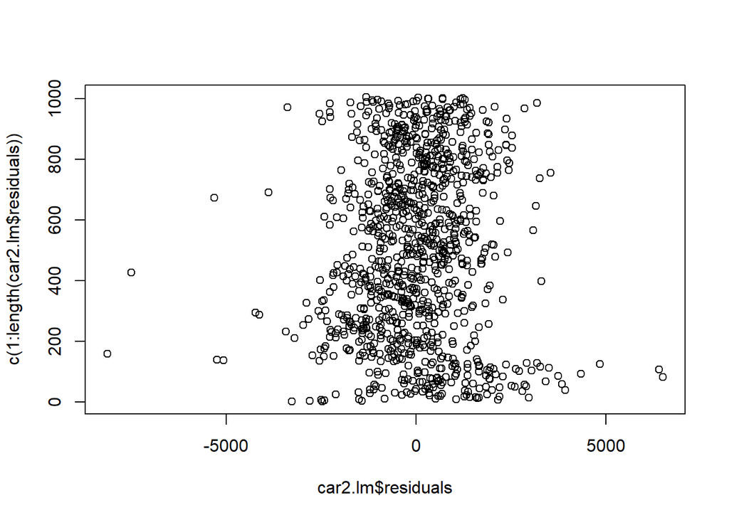

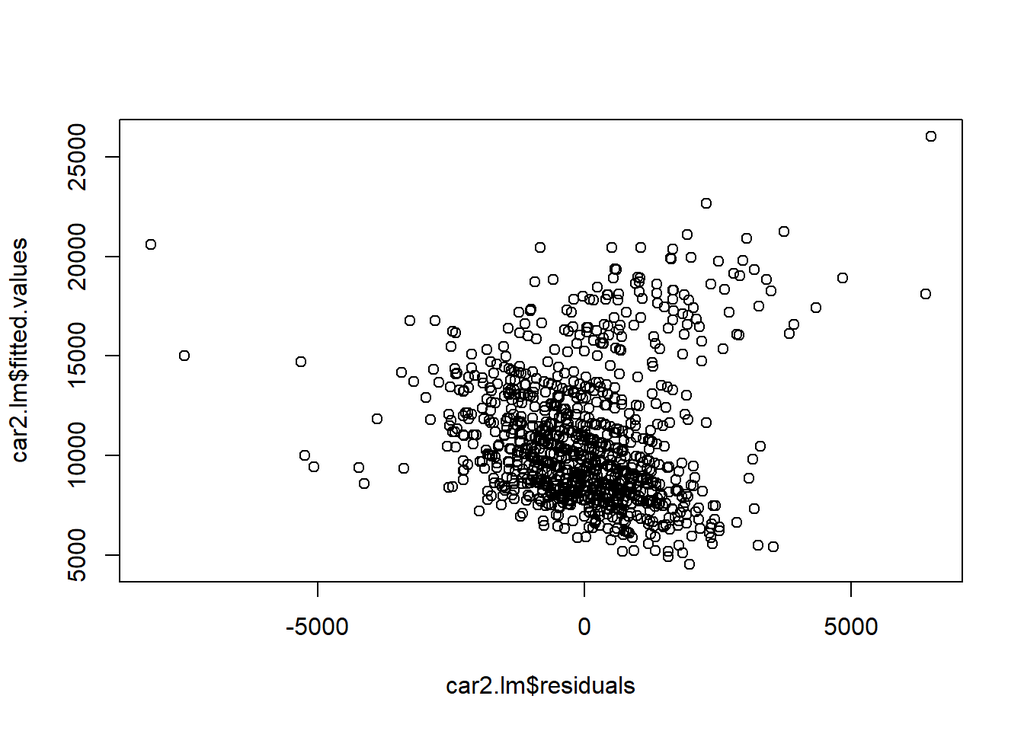

```
##
##  studentized Breusch-Pagan test
##
## data:  car2.lm
## BP = 284.45, df = 5, p-value < 0.00000000000000022
```

Heteroscedasticity means unequal scatter and produces a distinctive fan or cone shape in residual plots . Specifically, heteroscedasticity is a systematic change in the spread of the residuals over the range of measured value.

The test statistic is 284.45 and the corresponding p-value is< 0.00000000000000022 Since the p-value is less than 0.05, we can reject the null hypothesis. We have sufficient evidence to say that heteroscedasticity is present in the regression model.

Null Hypothesis (H0): Homoscedasticity is present (the residuals are distributed with equal variance) Alternative Hypothesis (HA): Heteroscedasticity is present (the residuals are not distributed with equal variance)

```
##   (Intercept)           Age            KM            HP        Weight
## -789.02888185 -121.73285968   -0.02110074   38.59234028   14.31185095
## Quarterly_Tax
##    5.74148366
```

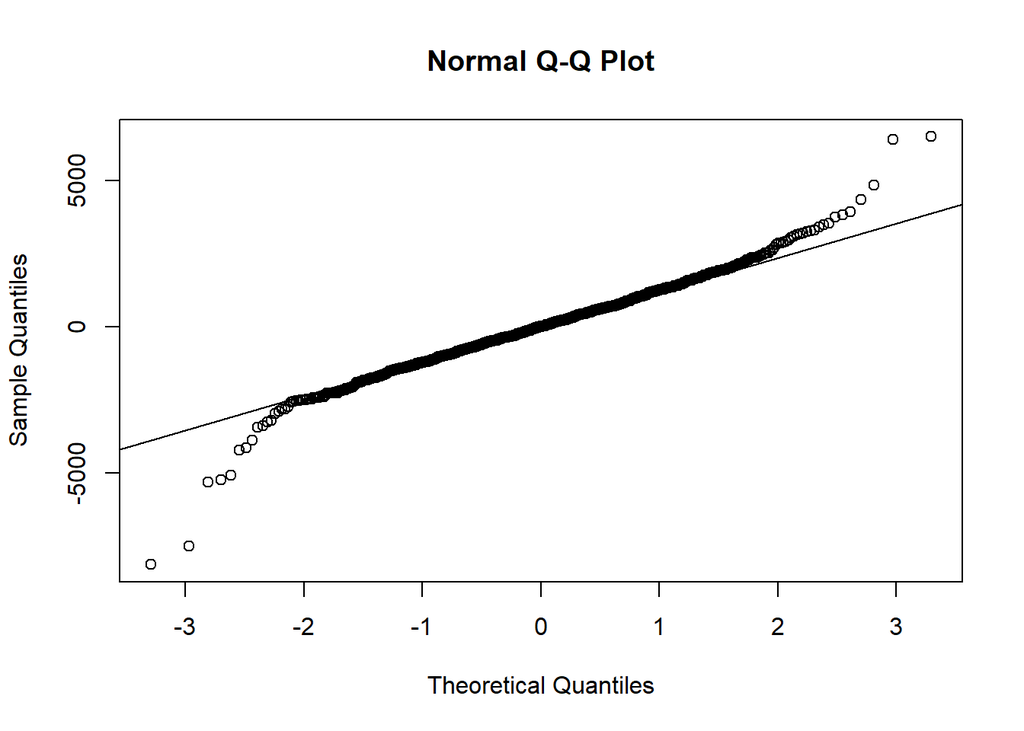

```
##
##  Shapiro-Wilk normality test
##
## data:  x
## W = 0.97111, p-value = 0.0000000000003005
```

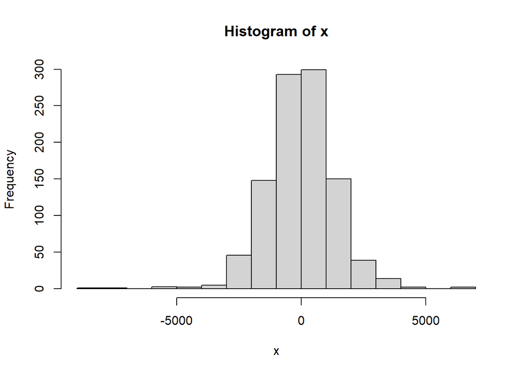

**EXPLANATION** Shapiro Test for Normality: Null hypothesis: Data is normally distributed Alternate Hypothesis: Data is not normally distributed

p-value = 0.0000000000003005. If the p-value is greater than 0.05, then the null hypothesis is not rejected. In this case, the p- value is less than 0.05 thus data is not normally distributed . Most of the data point lie on the line as seen from the Normal qq Plot.

```
##
##  Durbin-Watson test
##
## data:  car2.lm
## DW = 1.4759, p-value < 0.00000000000000022
## alternative hypothesis: true autocorrelation is greater than 0
```

**EXPLANATION** Autocorrelation occurs when the residuals are not independent from each other. The null hypothesis of the Durbin Watson test (Ho) is that there is no correlation among residuals, i.e., they are independent. The alternative hypothesis (Ha) is that residuals are autocorrelated.

We see that the resulting p-value is not greater than 0.05, and so we reject the null hypothesis. The D-W statistic for this model of 1.4759 which indicates a less positive correlation in the residuals data. In order to solve this and remove autocorrelation some more missing predictors(IVs) should be added to the regression model.

**PROBELM STATEMENT 2**

Determine the number of months left for vehicle to become eligible for vehicle scrapping. Cars older than 20 years are eligible for scrapping. A value of 0 indicates that the vehicle is eligble for vehicle scrapping

```
## [1] 202
```

```
## # A tibble: 1,436 x 11
##       Id Model          Price   Age    KM    HP    cc Doors Quarterly_Tax Weight
##    <dbl> <chr>          <dbl> <dbl> <dbl> <dbl> <dbl> <dbl>         <dbl>  <dbl>
##  1     1 TOYOTA Coroll~ 13500   225 46986    90  2000     3           210   1165
##  2     2 TOYOTA Coroll~ 13750   225 72937    90  2000     3           210   1165
##  3     3  TOYOTA Corol~ 13950   226 41711    90  2000     3           210   1165
##  4     4 TOYOTA Coroll~ 14950   228 48000    90  2000     3           210   1165
##  5     5 TOYOTA Coroll~ 13750   232 38500    90  2000     3           210   1170
##  6     6 TOYOTA Coroll~ 12950   234 61000    90  2000     3           210   1170
##  7     7  TOYOTA Corol~ 16900   229 94612    90  2000     3           210   1245
##  8     8 TOYOTA Coroll~ 18600   232 75889    90  2000     3           210   1245
##  9     9  TOYOTA Corol~ 21500   229 19700   192  1800     3           100   1185
## 10    10  TOYOTA Corol~ 12950   225 71138    69  1900     3           185   1105
## # ... with 1,426 more rows, and 1 more variable: MonthsLeft <dbl>
```

```
## [1] 1436   11
```

```
## # A tibble: 1,436 x 3
##       Id Model                                          MonthsLeft
##    <dbl> <chr>                                               <dbl>
##  1     1 TOYOTA Corolla 2.0 D4D HATCHB TERRA 2/3-Doors          15
##  2     2 TOYOTA Corolla 2.0 D4D HATCHB TERRA 2/3-Doors          15
##  3     3  TOYOTA Corolla 2.0 D4D HATCHB TERRA 2/3-Doors         14
##  4     4 TOYOTA Corolla 2.0 D4D HATCHB TERRA 2/3-Doors          12
##  5     5 TOYOTA Corolla 2.0 D4D HATCHB SOL 2/3-Doors             8
##  6     6 TOYOTA Corolla 2.0 D4D HATCHB SOL 2/3-Doors             6
##  7     7  TOYOTA Corolla 2.0 D4D 90 3DR TERRA 2/3-Doors         11
##  8     8 TOYOTA Corolla 2.0 D4D 90 3DR TERRA 2/3-Doors           8
##  9     9  TOYOTA Corolla 1800 T SPORT VVT I 2/3-Doors           11
## 10    10  TOYOTA Corolla 1.9 D HATCHB TERRA 2/3-Doors           15
## # ... with 1,426 more rows
```

**GRAPHS**

[output not shown]

[output cut: 690 more lines]

[output not shown]

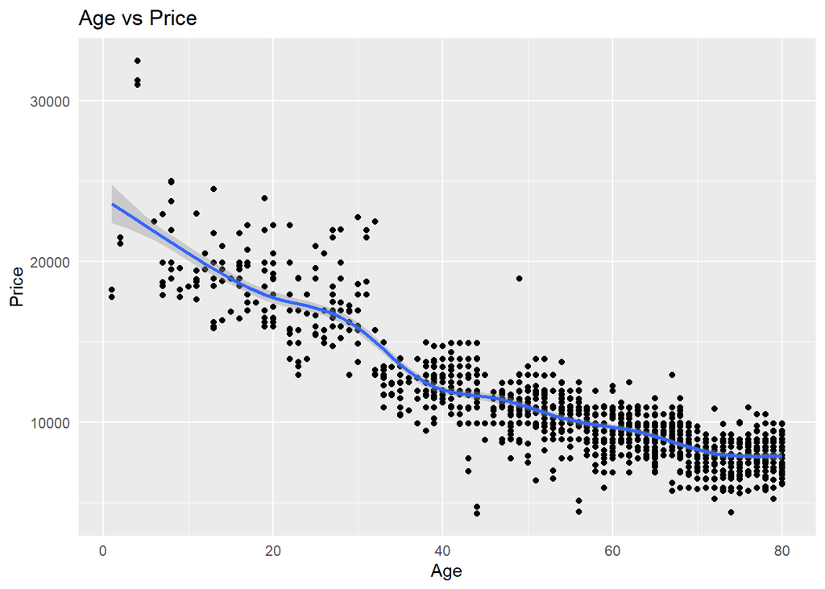

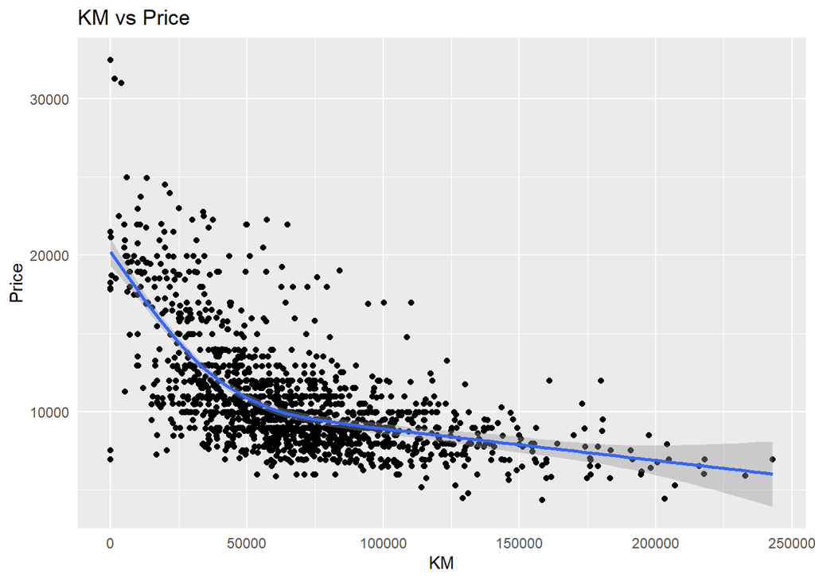

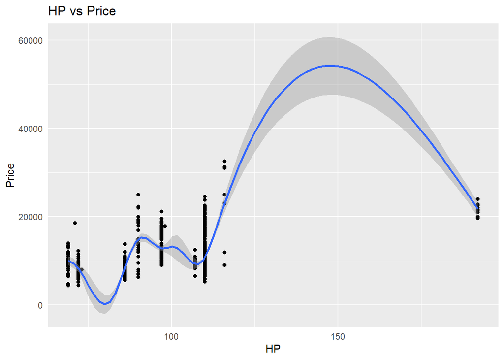

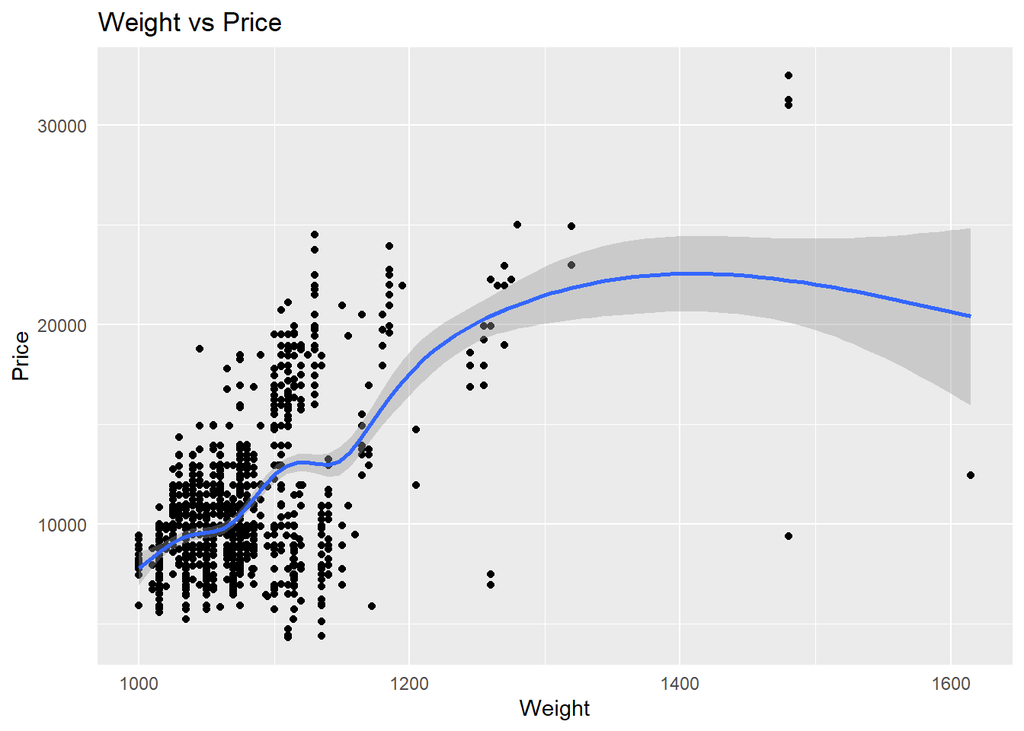

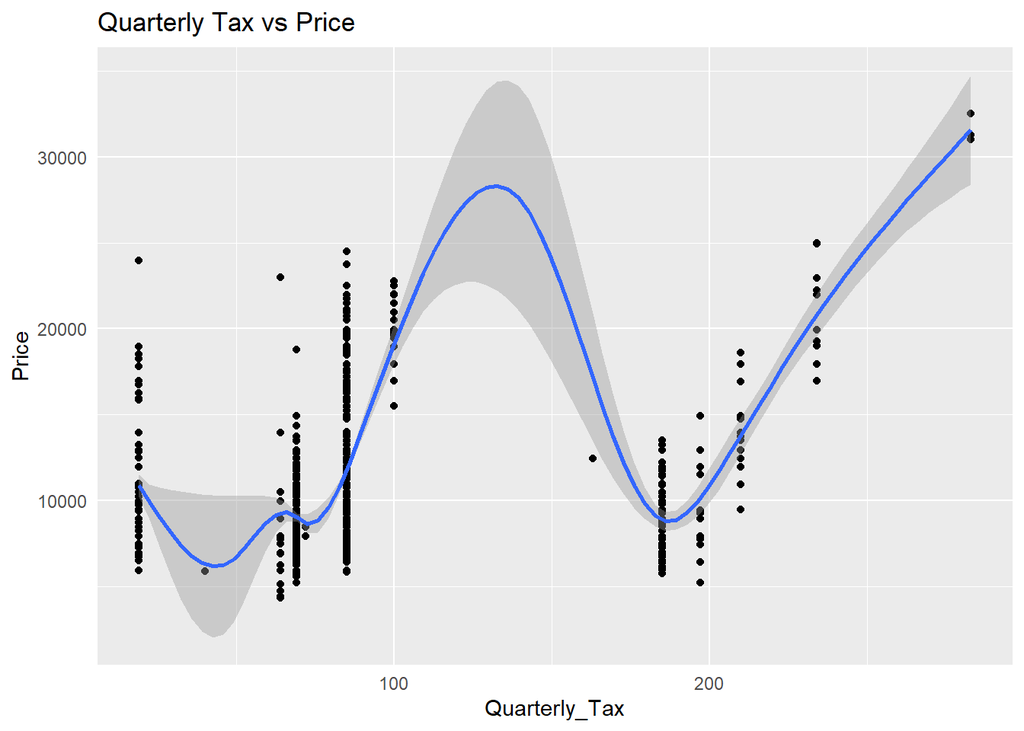

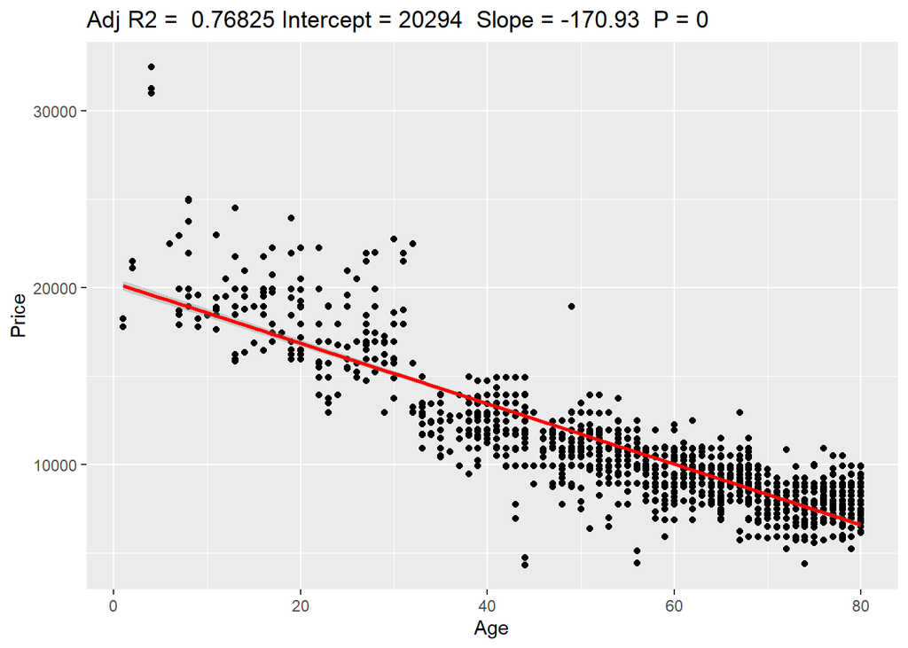

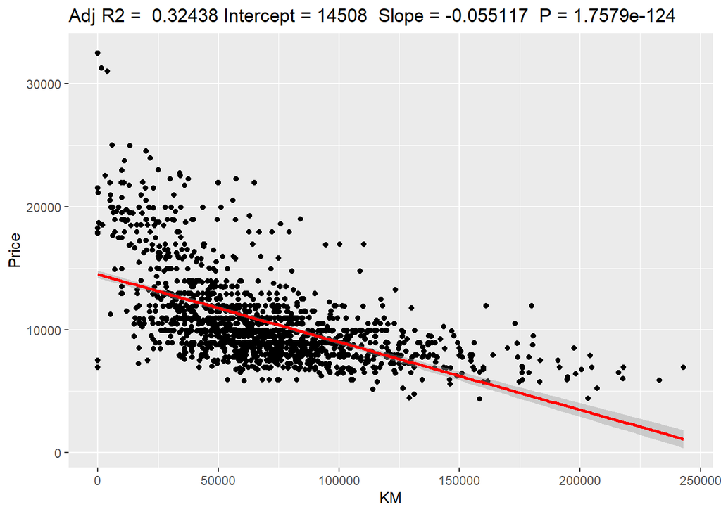